# The effect of environmental randomness is population-specific

Ignasi

23/12/2019

One of the conclusions in `2019-04-03` was that there is a significant interaction between the effects of the regime and of the original population. That means that not all populations responded equally to a specific selective regime. We need to take this into account to decide what contrasts are interesting. Not only the genes that are *on average* differently expressed in regular than in random environments are interesting. The specific response of each random population may have biological meaning.

On `2019-04-03` we also determined that there are no genes with a significant interaction between selective regime and hatching condition. This may be a simple consequence of the fact that not all populations respond similarly to the selective regimes: in this situation, there are just not enough replicates to detect an interaction between regime and hatching condition.

# Genes expressed *on average* differently between random and regular regimes

When I first tested the effect of randomness on expression level using model 4 and 6 on `2019-04-03`, I tested for a significant second coefficient, which corresponds to the expression level of a sample from original population 1 under a random regime, relative to the expression level of population 3, under a regular regime. That does not seem to be what I want. To make it easier to express a contrast that compares all random populations to all regular ones, I will use a different model.

```r
counts <- read.table(COUNTS_FILE, row.names=1, header=TRUE)
regimePop <- factor(c('random1',  'random1',  'random2',  'random2',
                      'regular1', 'regular1', 'random3',  'random3',
                      'regular2', 'regular2', 'regular3', 'regular3'))
diapause   <- factor(rep(c("hatch","diapause"), 6))
diapause   <- relevel(diapause, "hatch")

# Filtering
y <- DGEList(counts=counts, group=regimePop)
y <- calcNormFactors(y, method="TMM")
threshold <- 5.0 / (min(y$samples$lib.size) / 1000000)
keep <- rowSums(cpm(y) > threshold) >= 4
y <- y[keep, ,keep.lib.sizes=FALSE]
NumOfTags <- dim(y)[1]
design7 <- model.matrix(~ 0 + regimePop + diapause)
row.names(design7) <- names(counts)
reactable(design7, columns=list(
  regimePoprandom1 = colDef(name='Random.1'),
  regimePoprandom2 = colDef(name='Random.2'),
  regimePoprandom3 = colDef(name='Random.3'),
  regimePopregular1 = colDef(name='Regular.1'),
  regimePopregular2 = colDef(name='Regular.2'),
  regimePopregular3 = colDef(name='Regular.3'),
  diapausediapause = colDef(name='diapause')))
```

|  | Random.1 | Random.2 | Random.3 | Regular.1 | Regular.2 | Regular.3 | diapause |
| --- | --- | --- | --- | --- | --- | --- | --- |
| X1A_S8 | 1 | 0 | 0 | 0 | 0 | 0 | 0 |
| X1C_S1 | 1 | 0 | 0 | 0 | 0 | 0 | 1 |
| X2A_S7 | 0 | 1 | 0 | 0 | 0 | 0 | 0 |
| X2C_S5 | 0 | 1 | 0 | 0 | 0 | 0 | 1 |
| X3A_S9 | 0 | 0 | 0 | 1 | 0 | 0 | 0 |
| X3C_S11 | 0 | 0 | 0 | 1 | 0 | 0 | 1 |
| X4A_S6 | 0 | 0 | 1 | 0 | 0 | 0 | 0 |
| X4C_S12 | 0 | 0 | 1 | 0 | 0 | 0 | 1 |
| X5A_S2 | 0 | 0 | 0 | 0 | 1 | 0 | 0 |
| X5C_S4 | 0 | 0 | 0 | 0 | 1 | 0 | 1 |

[output cut: 2 more lines]

```r
y7 <- estimateDisp(y, design7)
fit7 <- glmQLFit(y7, design7)
randomness <- glmQLFTest(fit7, contrast = c(1/3, 1/3, 1/3, -1/3, -1/3, -1/3, 0))
```

By treating populations independently, model 7 neither assumes nor estimates whatever common effect populations in the same regime may share.

Instead of reporting the number of significantly regulated genes under a specific FDR, I report here the overall, FDR-independent, estimated fraction of regulated genes. There are ways to estimate the number of true null hypotheses even when there is a dependence structure among tests. I found the package `cp4p` (Gianetto et al. 2016. Proteomics, 16(1), 29-32.), that does exactly that. The SLIM method [Want et al. 2011](https://academic.oup.com/bioinformatics/article/27/2/225/286449), is supposed to be adequate for datasets with dependence structure, but I think here it overestimates the proportion of non-regulated genes.

```r
randomness.pi0 <- estim.pi0(randomness$table$PValue)
randomness.pi0
```

```
## $pi0.est
##   pi0.Storey.Spline pi0.Storey.Boot pi0.Jiang pi0.Histo pi0.Langaas pi0.Pounds
## 1         0.1985545       0.2086825 0.2062857  0.205709   0.2049333  0.2836633
##     pi0.ABH  pi0.SLIM
## 1 0.4006596 0.3954586
```

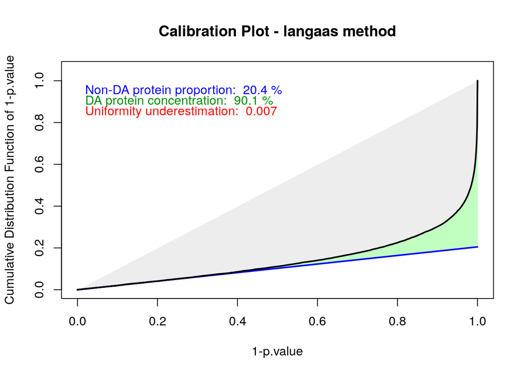

```
## $pi0
## [1] 0.2049333
##
## $h1.concentration
## [1] 0.9010333
##
## $unif.under
## [1] 0.007566121
```

```r
calibration.plot(randomness$table$PValue, pi0.method = 'langaas')
```

```r
topTags(randomness)
```

```
## Coefficient:  0.333333333333333*regimePoprandom1 0.333333333333333*regimePoprandom2 0.333333333333333*regimePoprandom3 -0.333333333333333*regimePopregular1 -0.333333333333333*regimePopregular2 -0.333333333333333*regimePopregular3
##                 logFC    logCPM        F       PValue         FDR
## XLOC_018218 -1.779483 4.4933016 247.8856 7.739315e-08 0.001431541
## XLOC_008190 -2.574294 2.9399883 152.7331 6.212916e-07 0.001933099
## XLOC_000631 -2.717127 3.4151275 149.3186 6.840127e-07 0.001933099
## XLOC_015546 -2.191895 3.3117674 138.7801 9.331196e-07 0.001933099
## XLOC_034150 -2.603784 2.5885594 134.6050 1.061862e-06 0.001933099
## XLOC_049880 -1.662504 5.6352566 127.7357 1.324632e-06 0.001933099
## XLOC_004338 -2.869504 0.7458014 124.2588 1.487883e-06 0.001933099
## XLOC_021971 -1.669050 3.1847354 121.5856 1.630359e-06 0.001933099
## XLOC_014686 -1.896352 2.9526885 116.3509 1.961038e-06 0.001933099
## XLOC_045709 -2.020514 7.3552693 115.4977 2.022442e-06 0.001933099
```

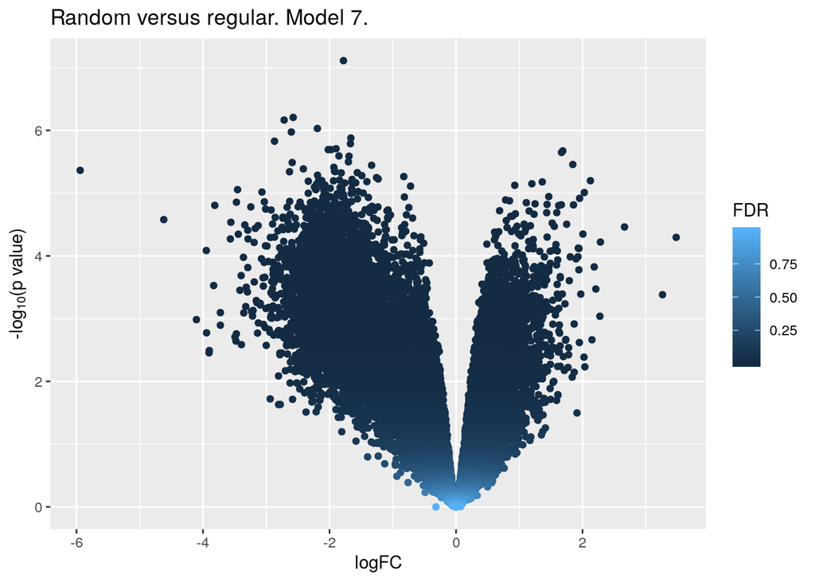

```r
z1 <- topTags(randomness, n=NumOfTags)$table
z1$logPValue <- -log10(z1$PValue)
ggplot(data=z1, mapping=aes(x=logFC, y=logPValue, color=FDR)) +
   geom_point() + theme_grey() + ylab(expression(paste("-log"[10], plain("(p value)")))) +
   ggtitle('Random versus regular. Model 7.')
```

```r
rm(z1)
```

According to this test, at least 60 and up to 80% of genes are differentially expressed on average between regular and random regimes.

# Genes expressed differently in random population 1 than in the average regular population

Using again model 7, now I want to determine what genes are expressed differently in random population 1, with respect to the average regular population.

```r
random1 <- glmQLFTest(fit7, contrast = c(1, 0, 0, -1/3, -1/3, -1/3, 0))
random1.pi0 <- estim.pi0(random1$table$PValue)
random1.pi0
```

```
## $pi0.est
##   pi0.Storey.Spline pi0.Storey.Boot pi0.Jiang pi0.Histo pi0.Langaas pi0.Pounds
## 1         0.3437472       0.3663297 0.3599923 0.3663297    0.358758  0.4866256
##     pi0.ABH  pi0.SLIM
## 1 0.7187652 0.6813816
```

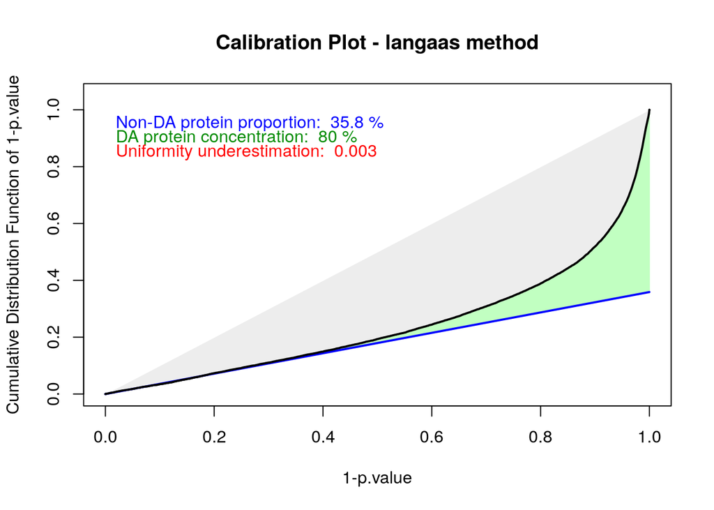

```
## $pi0
## [1] 0.358758
##
## $h1.concentration
## [1] 0.8003531
##
## $unif.under
## [1] 0.003510087
```

```r
calibration.plot(random1$table$PValue, pi0.method = 'langaas')
```

```r
topTags(random1)
```

```
## Coefficient:  1*regimePoprandom1 -0.333333333333333*regimePopregular1 -0.333333333333333*regimePopregular2 -0.333333333333333*regimePopregular3
##                 logFC     logCPM         F       PValue         FDR
## XLOC_020921 -1.526164  4.8276100 130.16580 1.223433e-06 0.008699822
## XLOC_043877 -2.988333  6.3759197 127.83521 1.320292e-06 0.008699822
## XLOC_000348  4.977064 -0.4217109 114.61780 2.088257e-06 0.008699822
## XLOC_029218  1.518759  3.7522225 108.21347 2.655336e-06 0.008699822
## XLOC_009724  2.886354  0.2635389 108.20022 2.656692e-06 0.008699822
## XLOC_005001  3.608456  2.1072006 106.64428 2.822021e-06 0.008699822
## XLOC_027395  3.191123  0.3868021  93.72042 4.821518e-06 0.010558090
## XLOC_012864  3.314003 -0.7740361  93.13954 4.946773e-06 0.010558090
## XLOC_024723  3.547371  2.0019190  92.29004 5.137201e-06 0.010558090
## XLOC_016275  1.770672  3.6656431  88.67346 6.055592e-06 0.011201028
```

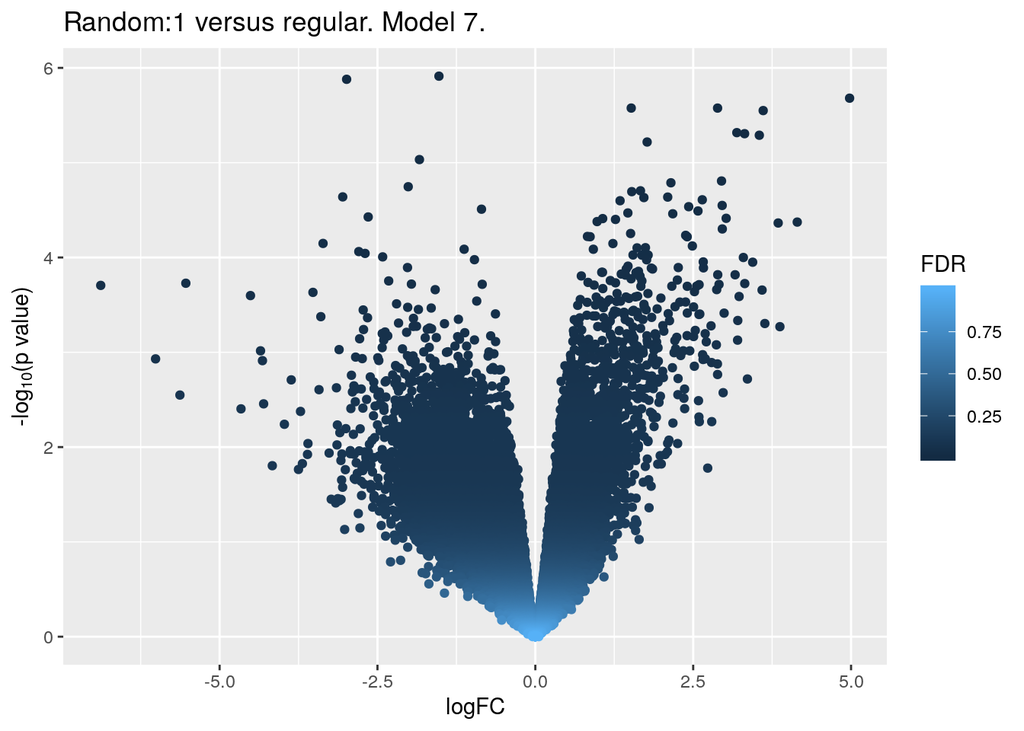

```r
z1 <- topTags(random1, n=NumOfTags)$table
z1$logPValue <- -log10(z1$PValue)
ggplot(data=z1, mapping=aes(x=logFC, y=logPValue, color=FDR)) +
   geom_point() + theme_grey() + ylab(expression(paste("-log"[10], plain("(p value)")))) +
   ggtitle('Random:1 versus regular. Model 7.')
```

```r
rm(z1)
```

According to this test, at least 28 and up to 66% of genes are expressed differently in population 1, under a random regime, relative to the average across populations in the regular regime.

# Genes expressed differently in random population 2 than in the average regular population

Next, we examine population 2, also under a random regime, relative to the average of populations under the regular regime.

```r
random2 <- glmQLFTest(fit7, contrast = c(0, 1, 0, -1/3, -1/3, -1/3, 0))
random2.pi0 <- estim.pi0(random2$table$PValue)
random2.pi0
```

```
## $pi0.est
##   pi0.Storey.Spline pi0.Storey.Boot pi0.Jiang pi0.Histo pi0.Langaas pi0.Pounds
## 1          0.211537       0.2321998 0.2127372 0.2011137   0.2240102  0.3191449
##     pi0.ABH  pi0.SLIM
## 1 0.5087852 0.4475173
```

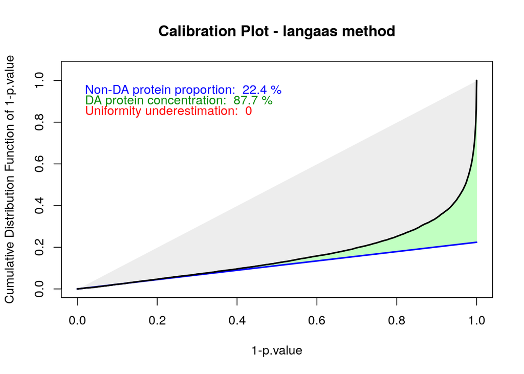

```
## $pi0
## [1] 0.2240102
##
## $h1.concentration
## [1] 0.8772125
##
## $unif.under
## [1] 0.0002453502
```

```r
calibration.plot(random2$table$PValue, pi0.method = 'langaas')
```

```r
topTags(random2)
```

```
## Coefficient:  1*regimePoprandom2 -0.333333333333333*regimePopregular1 -0.333333333333333*regimePopregular2 -0.333333333333333*regimePopregular3
##                 logFC    logCPM        F       PValue          FDR
## XLOC_018218 -3.605813 4.4933016 331.3825 2.183924e-08 0.0003096498
## XLOC_009554  3.338617 3.7825008 294.7038 3.645706e-08 0.0003096498
## XLOC_020688  2.539467 4.2577578 252.2554 7.173941e-08 0.0003096498
## XLOC_044284 -3.745885 5.6171833 247.1011 7.846510e-08 0.0003096498
## XLOC_015546 -5.674330 3.3117674 238.0563 9.223844e-08 0.0003096498
## XLOC_044910 -5.755328 2.1799765 233.4201 1.004432e-07 0.0003096498
## XLOC_000250  2.688658 2.5314970 187.8480 2.563979e-07 0.0005678433
## XLOC_011462  3.026039 2.0879037 181.1907 2.993595e-07 0.0005678433
## XLOC_017039 -6.786233 0.8030391 177.9228 3.236597e-07 0.0005678433
## XLOC_016593  1.619762 4.5014953 176.4682 3.352497e-07 0.0005678433
```

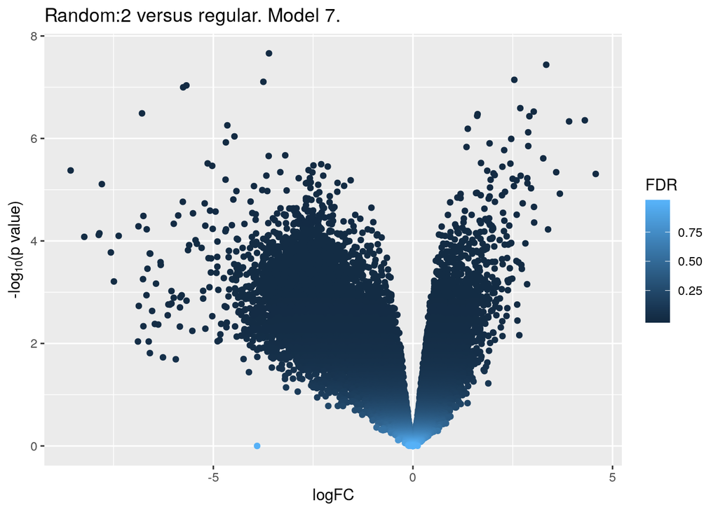

```r
z1 <- topTags(random2, n=NumOfTags)$table
z1$logPValue <- -log10(z1$PValue)
ggplot(data=z1, mapping=aes(x=logFC, y=logPValue, color=FDR)) +
   geom_point() + theme_grey() + ylab(expression(paste("-log"[10], plain("(p value)")))) +
   ggtitle('Random:2 versus regular. Model 7.')
```

```r
rm(z1)
```

According to this test, at least 49 and up to 80% of genes are expressed differently in population 2, under a random regime, relative to the average across populations in the regular regime.

# Genes expressed differently in (random) population 4 than in the average regular population

The third population under a random regime is labeled *4* in samples names. Let’s see what and how many genes are expressed differently in that population, relative to those under regular regime:

```r
random3 <- glmQLFTest(fit7, contrast = c(0, 0, 1, -1/3, -1/3, -1/3, 0))
random3.pi0 <- estim.pi0(random3$table$PValue)
random3.pi0
```

```
## $pi0.est
##   pi0.Storey.Spline pi0.Storey.Boot pi0.Jiang pi0.Histo pi0.Langaas pi0.Pounds
## 1          0.281892       0.2986971 0.2894163 0.2822079    0.294043  0.3985906
##     pi0.ABH  pi0.SLIM
## 1 0.5640374 0.5528824
```

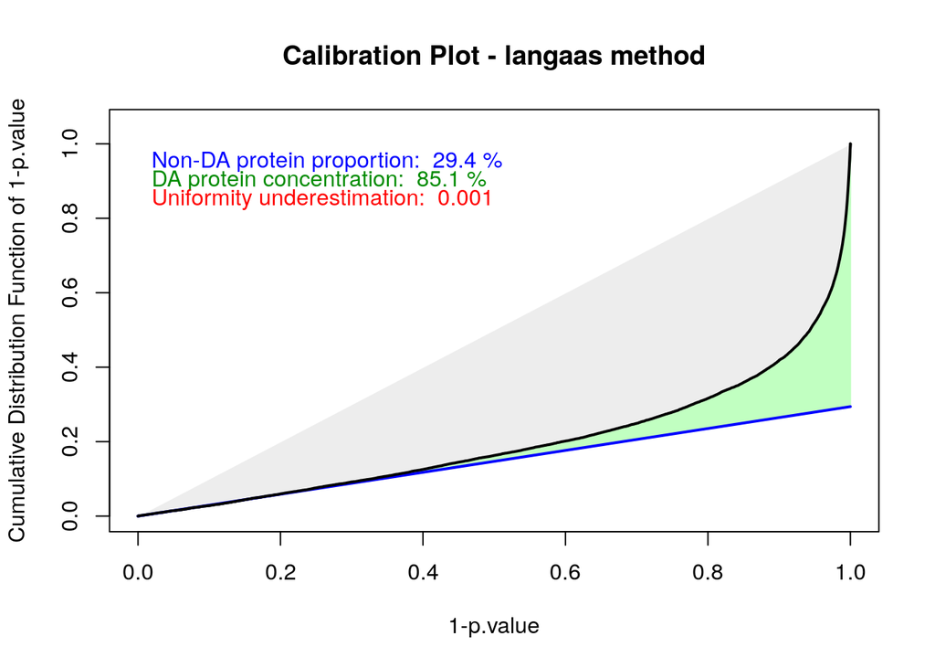

```
## $pi0
## [1] 0.294043
##
## $h1.concentration
## [1] 0.8517351
##
## $unif.under
## [1] 0.001115588
```

```r
calibration.plot(random3$table$PValue, pi0.method = 'langaas')
```

```r
topTags(random3)
```

```
## Coefficient:  1*regimePoprandom3 -0.333333333333333*regimePopregular1 -0.333333333333333*regimePopregular2 -0.333333333333333*regimePopregular3
##                 logFC   logCPM        F       PValue          FDR
## XLOC_017180  4.335914 2.027386 326.8569 2.319313e-08 0.0004290034
## XLOC_031557 -3.238958 4.128825 215.0547 1.431706e-07 0.0008831810
## XLOC_001420  1.432347 6.601563 215.0300 1.432418e-07 0.0008831810
## XLOC_039015  1.832653 4.838726 194.5843 2.203567e-07 0.0009909730
## XLOC_000631 -6.014771 3.415128 185.9430 2.678740e-07 0.0009909730
## XLOC_004889  2.375908 2.749019 175.1324 3.463432e-07 0.0010677184
## XLOC_003093  2.634974 3.296793 157.4242 5.461790e-07 0.0014432389
## XLOC_039146 -2.540396 3.169726 135.5521 1.030842e-06 0.0023834353
## XLOC_010274  2.001752 2.746965 123.8347 1.509439e-06 0.0031022320
## XLOC_018218 -1.853087 4.493302 114.3758 2.106819e-06 0.0038969824
```

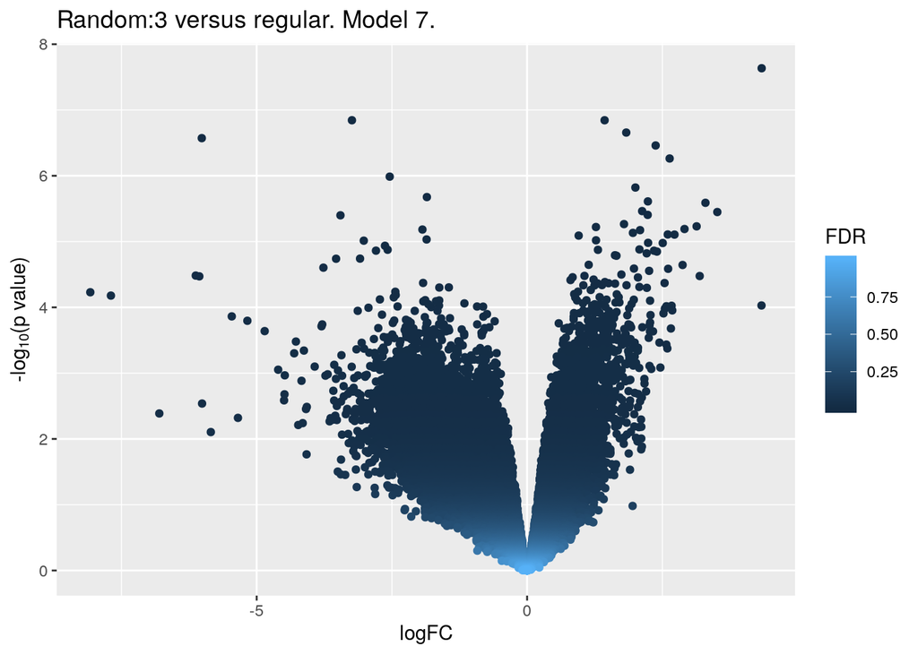

```r
z1 <- topTags(random3, n=NumOfTags)$table
z1$logPValue <- -log10(z1$PValue)
ggplot(data=z1, mapping=aes(x=logFC, y=logPValue, color=FDR)) +
   geom_point() + theme_grey() + ylab(expression(paste("-log"[10], plain("(p value)")))) +
   ggtitle('Random:3 versus regular. Model 7.')
```

```r
rm(z1)
```

According to this test, at least 44 and up to 72% of genes are expressed differently in population 3, under a random regime, relative to the average across populations in the regular regime.

# Genes always expressed differently in a random population than in the average regular population

The scatterplot of p-values is not expected to produce any visible correlation, unless for the smallest p-values. Plotting p-values in logarithmic scale does show that many genes differentially expressed in any population under the random regime is also differentially expressed in the other populations in the same regime.

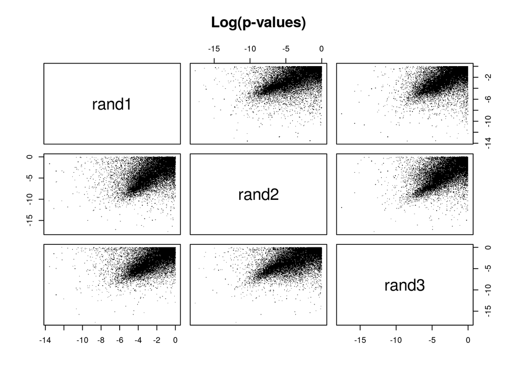

```r
pairs(data.frame(rand1=log(random1$table$PValue),
                 rand2=log(random2$table$PValue),
                 rand3=log(random3$table$PValue)),
      pch=".", main='Log(p-values)')
```

What about the log-fold change? Does the random regime change gene expression in the same direction in all populations? Yes:

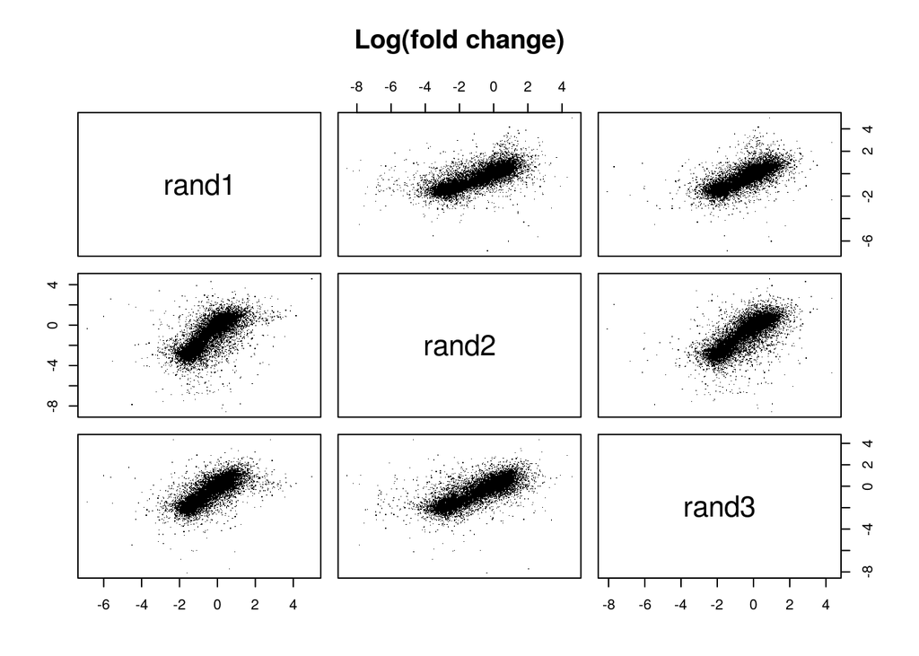

```r
pairs(data.frame(rand1=random1$table$logFC,
                 rand2=random2$table$logFC,
                 rand3=random3$table$logFC),
      pch = ".", main = 'Log(fold change)')
```

Given the large number of regulated genes, I can use a conservative FDR to compare the most significantly regulated genes among populations in the random regime.

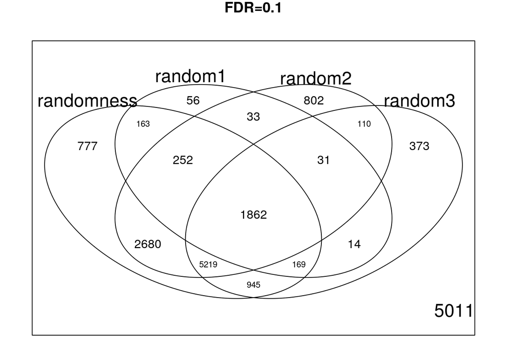

```r
significant <- cbind(randomness = topTags(randomness, n=NumOfTags, sort.by='none', adjust.method='fdr')$table$FDR <= 0.1,
                     random1 = topTags(random1, n=NumOfTags, sort.by='none', adjust.method='fdr')$table$FDR <= 0.1,
                     random2 = topTags(random2, n=NumOfTags, sort.by='none', adjust.method='fdr')$table$FDR <= 0.1,
                     random3 = topTags(random3, n=NumOfTags, sort.by='none', adjust.method='fdr')$table$FDR <= 0.1)
vennDiagram(vennCounts(significant), main='FDR=0.1')
```

# Writing up the results

I should save the results of the `glmQLFTest()` to run the functional analysis on the lists of regulated genes in a different session.

```r
save(randomness, random1, random2, random3, file = 'RegimeEffect_model7.RData')
```